# Práctica 1- Manuel Cota

Manuel Cota

2024-05-29

## Ejercicio 1

#### En una empresa se realizan frecuentemente pruebas para detectar COVID entre los trabajadores, como ejercicio de prevención. De registros previos, se sabe que 1 de cada 10 resultan positivos a la prueba. Si en cada ejercicio se aplican pruebas a 20 trabajadores y debido a las medidas de seguridad, se puede suponer que el estado de salud de un trabajador es independiente del estado de salud de los demás.

#### 1: ¿Cuál esla probabilidad de que en esos 20 sujetos elegidos resulten positivos exactamente 2 de ellos?

$X =$ cantidad de casospositivos en la muestra de $20$ trabajadores, entonces $X \sim Binomial(n=20, p=1/10)$.

Queremos calcular $P[X = 2] = f(2)$.

```r
dbinom(2, 20, 0.1)
```

```
## [1] 0.2851798
```

#### 2: Calcular la probabilidad de que resulten a lo más 5 trabajadores positivos a COVID.

Queremos calcular $P[X \leq 5] = F(5) = f(0) + f(1) + f(2) + f(3) + f(4) + f(5)$

```r
sum(dbinom(0:5, 20, 0.1))
```

```
## [1] 0.9887469
```

```r
pbinom(5, 20, 0.1)
```

```
## [1] 0.9887469
```

#### 3: ¿Cual es la probabilidad de que resulten por lo menos 3 positivos a COIVD?

Queremos caluclar $P[X \geq 3] = f(3) + f(4) + ... + f(19) + f(20)$

O, dicho de otro modo, $P[X \geq] = 1 - F(2)$

```r
1 - pbinom(2, 20, 0.1)
```

```
## [1] 0.3230732
```

# ———————————————————-

# Dia 2

# ———————————————————-

#### 4: Grafique la función de probabilidad.

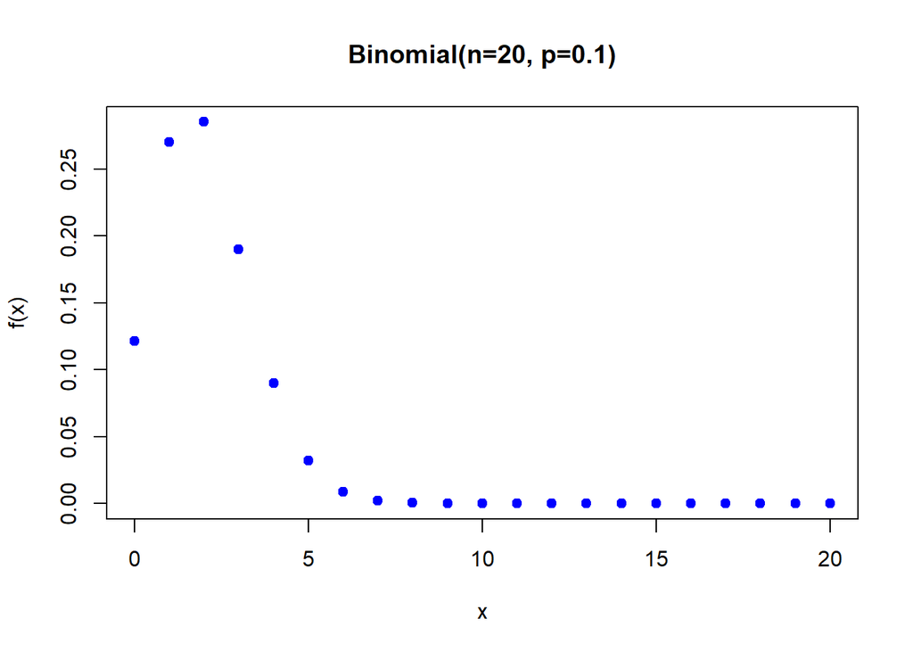

```r
x <- seq(0, 20, 1)
tabla.prob <- data.frame( x = x, Probabilidad = dbinom(x, 20, 0.1) )

plot(tabla.prob, main="Binomial(n=20, p=0.1)", pch = 19, ylab = "f(x)", col = "blue")
```

#### 6: Genere 1000 muestras aleatorias con esta distribución (simulando que se ha repetido el ejercicio de prevención contra COVID 1000 veces). Calcule las frecuencias relativas y compare con las probabilidades teóricas de la gráfica en el inciso anterior.

```r
muestras <- rbinom(n=1000, size=20, prob=0.1)
muestras
```

[output not shown]

Elaboremos una tabla de frecuencias de las muestras obtenidas.

```r
table(muestras)
```

```
## muestras
##   0   1   2   3   4   5   6   7   8
## 120 281 265 192  90  38  12   1   1
```

```r
prop.table( table(muestras) )
```

```
## muestras
##     0     1     2     3     4     5     6     7     8
## 0.120 0.281 0.265 0.192 0.090 0.038 0.012 0.001 0.001
```